# Teacher material: Kernel Density Estimation

Companion to unit 07: bandwidth and sample size

Livio Finos, University of Padova

# Lesson preparation

Suggested timing: 75 minutes of teaching plus 30-45 minutes of practical work. The student handout is `07_kde_bandwidth_sample_size.Rmd`. It contains the explanations and activities, but no teacher prompts or hidden worked answers. This companion holds the facilitation notes and suggested answers separately.

The normal-mixture simulations are retained because they provide a known population density for distinguishing bias from variability. The real `faithful` and `rivers` examples are descriptive; there is no known population density to overlay and their collection does not establish independent random sampling.

```r
rmarkdown::render("07_kde_bandwidth_sample_size.Rmd",
                  output_format = "html_document")
rmarkdown::render("07_kde_bandwidth_sample_size_teacher.Rmd")
```

The student document’s `simulation_reps` parameter controls Monte Carlo precision; use at least 20 repetitions for a quick check and the default 120 for the handout. It does not change the size of the simulated samples.

# Suggested teaching sequence

Start with individual kernels and ask students to point to an observation, its own contribution, and the sum. Distinguish the mode of a Gaussian contribution from the modes of the sum. Define bandwidth before interpreting any change in the curves.

For the mixture bandwidth panels, **before revealing the truth**, ask students to count the apparent peaks. Hide the generating-density overlay temporarily if using these plots live, then compare their interpretations with it. A wiggle is not automatically a population subgroup; a wide bandwidth can also hide population structure.

Introduce Sheather-Jones as an estimate of the bias-variability balance using pilot estimates of curvature. The solve-the-equation derivation and the leave-one-out cross-validation derivation are optional for this level. Distinguish the sample size from `density()`’s evaluation-grid argument `n`.

For the kernel comparison, hold data, bandwidth and axes fixed. Then change only bandwidth. Rectangular kernels provide a useful example of local roughness without changing the broad waiting-time structure. Compact support relative to an observation is not a correction for the variable’s boundary.

# Activity 1: units and probability

Use the positive durations supplied in the activity, not `x_small`. Bandwidth 12 seconds corresponds to 0.2 minutes. Density per minute is 60 times density per second at matching locations. When converting the minutes curve back to seconds, multiply its x coordinates by 60 and divide its heights by 60. The curves should overlap.

For a Gaussian KDE the interval probability can be computed exactly:

```r
duration_seconds <- c(25, 35, 48, 60, 74, 90, 110, 135)
h_seconds <- 12
duration_minutes <- duration_seconds / 60
h_minutes <- h_seconds / 60
p_seconds <- mean(pnorm((90 - duration_seconds) / h_seconds) -
                  pnorm((30 - duration_seconds) / h_seconds))
p_minutes <- mean(pnorm((1.5 - duration_minutes) / h_minutes) -
                  pnorm((0.5 - duration_minutes) / h_minutes))
c(seconds = p_seconds, minutes = p_minutes)
```

```
##   seconds   minutes
## 0.5471354 0.5471354
```

```r
stopifnot(isTRUE(all.equal(p_seconds, p_minutes)))
```

Assessment: a consistent conversion of both axes, matching probabilities, and an explanation in terms of probability as area rather than height alone.

# Activity 2: real waiting times

Look for the broad short-wait and long-wait regions and check their persistence across the three bandwidths. Narrow bandwidths add local detail; wide ones blur it. Peaks alone do not identify latent population groups. Discuss rounding and why these data cannot validate an independence assumption.

# Activity 3: sample size versus smoothing

At fixed bandwidth, sampling variability decreases with independent sample size, while smoothing bias remains. Small random peaks tend to become less prominent; this need not happen monotonically in every nested sample sequence. Replicating observations produces the same KDE, not additional independent information. Use several seeds before drawing a conclusion.

# Activity 4: repeated samples

Small bandwidths produce greater variability; large bandwidths blur modes and increase smoothing bias. More observations reduce variability at fixed bandwidth, not its bias. More simulation repetitions improve the Monte Carlo estimates of those properties without changing the estimator. Ask students to describe the repeated curves before inspecting the error table, even if both appear in the handout.

# Activity 5: automatic bandwidth

Students should report the actual `nrd0` and `SJ` values for eruption duration, show sensitivity plots in minutes, and identify persistent broad features. Sheather-Jones estimates curvature rather than relying only on spread; neither selector guarantees that every peak is meaningful. The `n` argument of `density()` controls grid resolution; `adjust` changes smoothing.

# Activity 6: kernels

Compare broad waiting-time regions rather than tiny wiggles. Differences between kernels mostly affect local shape in this example, while widening the bandwidth changes resolution. The activity plot uses solid lines and colours to identify kernels. Equal bandwidth in R means equal kernel standard deviation, not identical support or exactly equal risk.

# Activity 7: support and the log transformation

For positive measurements, fit a KDE to their logarithms and calculate `density_log(log(x)) / x` at positive original-scale grid points. The derivative `d log(x) / dx = 1/x` converts horizontal interval widths; the same factor converts heights to preserve probability as area. Calling this a Jacobian is mathematically correct, but start with interval widths.

The log-transformed estimate respects positivity. It is not the true density, and it smooths relative, rather than absolute, differences. The ordinary Gaussian KDE’s negative mass is `mean(pnorm(-river_lengths / h_river))`. Simply clipping the ordinary plot at zero does not repair the estimator. River lengths describe the supplied collection of major rivers, not all rivers sampled at random.

# Activity 8: custom KDEs on faithful waiting times

The student activity is last in the unit and uses the 272 real observations in `datasets::faithful$waiting`, measured in minutes. Its main comparison uses a common **kernel standard deviation**, including the Gaussian curve. The old equal-raw-scale comparison has been replaced; the scale conversion is part of both custom functions, not an optional adjustment in a later plot.

The U-shaped kernel is valid, with integral one and raw variance $3/5$. The rectangular raw variance is $1/3$. For a requested kernel SD $h$ use raw scales $s_R=h\sqrt3$ and $s_U=h\sqrt{5/3}$. Then $s_K\sigma_K=h$. The raw scales describe different support widths; they should not be called equal-SD bandwidths until this conversion has been made.

The data already have two broad waiting-time regions. Avoid the previous tight-cluster interpretation: there is no known population density, and two broad peaks cannot simply be blamed on the U-shaped kernel. Discuss local irregularity, rounding, sensitivity to smoothing, and the raw observations.

## Worked functions: h is the common kernel SD

```r
check_kde_inputs <- function(x, grid, h) {
  stopifnot(is.numeric(x), length(x) > 0L, all(is.finite(x)),
            is.numeric(grid), all(is.finite(grid)),
            is.numeric(h), length(h) == 1L, is.finite(h), h > 0)
}
K_rectangular <- function(u) .5 * (abs(u) <= 1)
K_u_shape <- function(u) 1.5 * u^2 * (abs(u) <= 1)

kde_rectangular <- function(x, grid, h) {
  check_kde_inputs(x, grid, h)
  scale <- h / sqrt(1 / 3)
  vapply(grid, function(t)
    mean(K_rectangular((t - x) / scale)) / scale, numeric(1))
}
kde_u_shape <- function(x, grid, h) {
  check_kde_inputs(x, grid, h)
  scale <- h / sqrt(3 / 5)
  vapply(grid, function(t)
    mean(K_u_shape((t - x) / scale)) / scale, numeric(1))
}
kde_gaussian <- function(x, grid, h) {
  check_kde_inputs(x, grid, h)
  vapply(grid, function(t)
    mean(dnorm((t - x) / h)) / h, numeric(1))
}

x_activity <- datasets::faithful$waiting
h_activity <- bw.SJ(x_activity)
adjust_activity <- c(.5, 1, 2)
grid_activity <- seq(min(x_activity) - 4 * max(adjust_activity) * h_activity,
                     max(x_activity) + 4 * max(adjust_activity) * h_activity,
                     length.out = 8193)
h_values_activity <- adjust_activity * h_activity
```

SJ supplies an exploratory Gaussian reference bandwidth, approximately 2.50 minutes. Use it to fix a comparison scale; this does not optimise the bandwidth for each custom kernel. The following table makes the conversion explicit for every requested resolution.

```r
scale_table <- data.frame(
  adjustment = adjust_activity,
  kernel_sd_minutes = h_values_activity,
  rectangular_raw_scale_minutes = h_values_activity * sqrt(3),
  u_shaped_raw_scale_minutes = h_values_activity * sqrt(5 / 3),
  gaussian_scale_minutes = h_values_activity
)
knitr::kable(scale_table, digits = 3)
```

| adjustment | kernel_sd_minutes | rectangular_raw_scale_minutes | u_shaped_raw_scale_minutes | gaussian_scale_minutes |
| --- | --- | --- | --- | --- |
| 0.5 | 1.252 | 2.169 | 1.617 | 1.252 |
| 1.0 | 2.504 | 4.338 | 3.233 | 2.504 |
| 2.0 | 5.009 | 8.675 | 6.466 | 5.009 |

## Raw kernel shapes

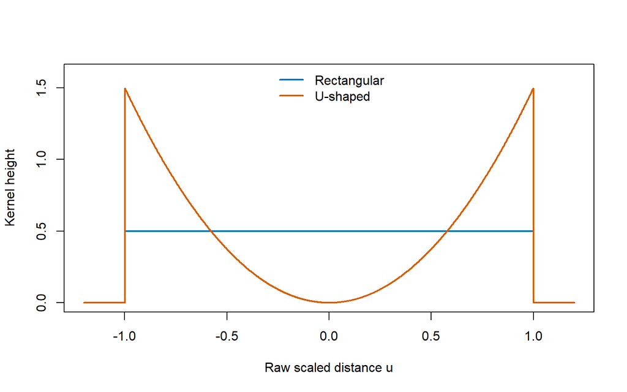

Raw kernels with equal support but different variances. The KDE functions convert their scales to a common SD.

```r
u_grid <- seq(-1.2, 1.2, length.out = 1001)
plot(u_grid, K_rectangular(u_grid), type = "l", col = "#0072B2", lwd = 2,
     ylim = c(0, 1.6), xlab = "Raw scaled distance u", ylab = "Kernel height")
lines(u_grid, K_u_shape(u_grid), col = "#D55E00", lwd = 2)
legend("top", c("Rectangular", "U-shaped"),
       col = c("#0072B2", "#D55E00"), lty = 1, lwd = 2, bty = "n")
```

## Main comparison: all three kernels have the same SD

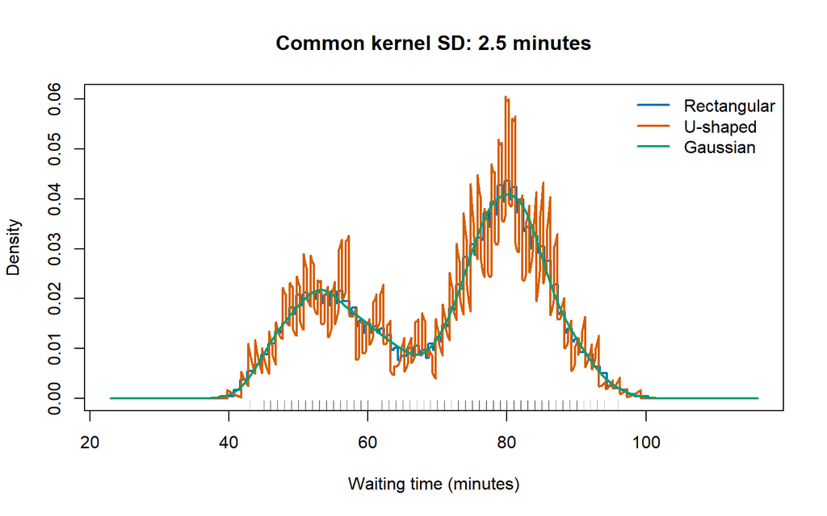

Faithful waiting times: every curve uses the same kernel SD, the SJ reference value. Support widths and shapes differ.

```r
y_rect <- kde_rectangular(x_activity, grid_activity, h_activity)
y_u <- kde_u_shape(x_activity, grid_activity, h_activity)
y_gauss <- kde_gaussian(x_activity, grid_activity, h_activity)
plot(grid_activity, y_rect, type = "l", col = "#0072B2", lwd = 2,
     ylim = c(0, max(y_rect, y_u, y_gauss)),
     xlab = "Waiting time (minutes)", ylab = "Density",
     main = paste("Common kernel SD:", round(h_activity, 2), "minutes"))
lines(grid_activity, y_u, col = "#D55E00", lwd = 2)
lines(grid_activity, y_gauss, col = "#009E73", lwd = 2)
rug(x_activity, col = grDevices::adjustcolor("black", .25))
legend("topright", c("Rectangular", "U-shaped", "Gaussian"),
       col = c("#0072B2", "#D55E00", "#009E73"), lty = 1, lwd = 2, bty = "n")
```

## Sensitivity at matched SDs

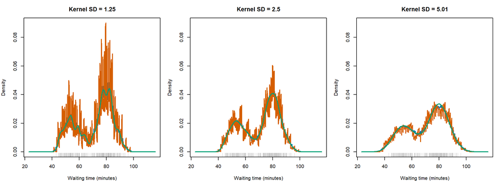

Within each panel, all three kernel SDs are equal. Between panels only the common SD changes; the data, grid and axes stay fixed.

```r
activity_curves <- lapply(h_values_activity, function(h)
  cbind(Rectangular = kde_rectangular(x_activity, grid_activity, h),
        U_shaped = kde_u_shape(x_activity, grid_activity, h),
        Gaussian = kde_gaussian(x_activity, grid_activity, h)))
local({
  old_par <- par(mfrow = c(1, 3), mar = c(4, 4, 3, 1))
  on.exit(par(old_par))
  common_ylim <- c(0, max(vapply(activity_curves, max, numeric(1))))
  for (j in seq_along(activity_curves)) {
    matplot(grid_activity, activity_curves[[j]], type = "l", lty = 1,
            col = c("#0072B2", "#D55E00", "#009E73"), lwd = 2,
            xlim = range(grid_activity), ylim = common_ylim,
            xlab = "Waiting time (minutes)", ylab = "Density",
            main = paste("Kernel SD =", round(h_values_activity[j], 2)))
    rug(x_activity, col = grDevices::adjustcolor("black", .2))
  }
})
```

The colours are the same as in the main comparison. Use the narrowest panel to discuss rounding and local irregularity, then identify broad features that persist at larger smoothing scales. Do not promise that the U-shaped kernel is always worse: interpretation must follow the displayed evidence.

## Numerical verification of SD and normalization

```r
trapz <- function(x, y) sum(diff(x) * (head(y, -1) + tail(y, -1)) / 2)
stopifnot(abs(integrate(K_rectangular, -1, 1)$value - 1) < 1e-8,
          abs(integrate(K_u_shape, -1, 1)$value - 1) < 1e-8)
variance_checks <- lapply(h_values_activity, function(h) {
  s_rect <- h / sqrt(1 / 3)
  s_u <- h / sqrt(3 / 5)
  var_rect <- integrate(function(t)
    t^2 * K_rectangular(t / s_rect) / s_rect, -s_rect, s_rect)$value
  var_u <- integrate(function(t)
    t^2 * K_u_shape(t / s_u) / s_u, -s_u, s_u)$value
  stopifnot(abs(var_rect - h^2) < 1e-7,
            abs(var_u - h^2) < 1e-7)
  data.frame(requested_sd = h, rectangular_sd = sqrt(var_rect),
             u_shaped_sd = sqrt(var_u), gaussian_sd = h)
})
knitr::kable(do.call(rbind, variance_checks), digits = 5)
```

| requested_sd | rectangular_sd | u_shaped_sd | gaussian_sd |
| --- | --- | --- | --- |
| 1.25219 | 1.25219 | 1.25219 | 1.25219 |
| 2.50437 | 2.50437 | 2.50437 | 2.50437 |
| 5.00874 | 5.00874 | 5.00874 | 5.00874 |

```r
area_checks <- lapply(seq_along(activity_curves), function(j) {
  curves <- activity_curves[[j]]
  areas <- apply(curves, 2, function(y) trapz(grid_activity, y))
  stopifnot(all(curves >= 0), all(abs(areas - 1) < .005))
  data.frame(kernel_sd = h_values_activity[j], t(areas),
             check.names = FALSE)
})
knitr::kable(do.call(rbind, area_checks), digits = 5)
```

| kernel_sd | Rectangular | U_shaped | Gaussian |
| --- | --- | --- | --- |
| 1.25219 | 1.00021 | 1.00102 | 1 |
| 2.50437 | 1.00002 | 0.99959 | 1 |
| 5.00874 | 0.99994 | 0.99986 | 1 |

Assess the scale conversion, normalization, common axes, and an interpretation grounded in the waiting times. If students compare equal raw scales as an extension, explicitly label that as a different experiment: the kernel SDs then differ. The normalisation check establishes a valid density, not the best estimator of the unknown population density.